# Assignment 3 - Performance Estimation

James McKinlay - B00867096

Question: Determining best model for predicting price based on other numerical attributes in data set.

# Introduction:

For this assignment, I will be using the import_85 automobile data set. This data set is from the Machine Learning Repository, at the Center for Machine Learning and Intelligent Systems (https://archive.ics.uci.edu/ml/datasets/Automobile). This data set contains 26 different attributes for automobiles, ranging from safety ratings, insurance risks, vehicle specifications, and average loss information. It contains this information on a number of different manufacturers, some located in North America, some from Europe, and some from Asia.  
There is a small amount of missing data, which will be handled in the data preperation phase of the assignment.

I will be attempting to determine which model will best predict vehicle price based on all other numerical attributes. In order to accomplish this, I will be testing three different models: linear regression, random forest, and support vector machines.

I will be using regression metrics to determine the mean squared error (mse) and the root mean squared error (rmse) and comparing it to the predicted mse/rmse. These will be used as my evaluation metrics

## Data And Libraries:

```r
library(tidyverse)
library(e1071)
library(MASS)
library(DMwR2)
library(performanceEstimation)
library(randomForest)
```

```r
library(rpart)
library(rpart.plot)
```

In this code chunk, I will be parsing the .names file of the given data set and assigning all column names properly.

```r
text <- read_lines("C:/Users/jmcki/OneDrive/Desktop/School/3141/CSCI3141_Assignment3_James_McKinlay_B00867096/imports-85.names")
#text[61:89]
names <- str_split_fixed(text[61:89], "\\. ",n=2)[,2]
names <- str_split_fixed(names, ":", n=2)[,1]
names <- names[-4:-6]
names <- make.names(names)
colnames(import_data)[1:26] <- names
#which(import_data=="?")
import_data <- replace(import_data, import_data=="?", NA)
import_data[, c(26)] <- sapply(import_data[, c(26)], as.numeric)
head(import_data)
```

```
##   symboling normalized.losses        make fuel.type aspiration num.of.doors
## 1         3              <NA> alfa-romero       gas        std          two
## 2         1              <NA> alfa-romero       gas        std          two
## 3         2               164        audi       gas        std         four
## 4         2               164        audi       gas        std         four
## 5         2              <NA>        audi       gas        std          two
## 6         1               158        audi       gas        std         four
##    body.style drive.wheels engine.location wheel.base length width height
## 1 convertible          rwd           front       88.6  168.8  64.1   48.8
## 2   hatchback          rwd           front       94.5  171.2  65.5   52.4
## 3       sedan          fwd           front       99.8  176.6  66.2   54.3
## 4       sedan          4wd           front       99.4  176.6  66.4   54.3
## 5       sedan          fwd           front       99.8  177.3  66.3   53.1
## 6       sedan          fwd           front      105.8  192.7  71.4   55.7
##   curb.weight engine.type num.of.cylinders engine.size fuel.system bore stroke
## 1        2548        dohc             four         130        mpfi 3.47   2.68
## 2        2823        ohcv              six         152        mpfi 2.68   3.47
## 3        2337         ohc             four         109        mpfi 3.19   3.40
## 4        2824         ohc             five         136        mpfi 3.19   3.40
## 5        2507         ohc             five         136        mpfi 3.19   3.40
## 6        2844         ohc             five         136        mpfi 3.19   3.40
##   compression.ratio horsepower peak.rpm city.mpg highway.mpg price
## 1               9.0        111     5000       21          27 16500
## 2               9.0        154     5000       19          26 16500
## 3              10.0        102     5500       24          30 13950
## 4               8.0        115     5500       18          22 17450
## 5               8.5        110     5500       19          25 15250
## 6               8.5        110     5500       19          25 17710
```

As you can see from the above data frame, there is some missing data included in the data set (focused mostly on the normalized.losses). These missing bits of data will be filled in using the mean of the training data in a later step.

In this section, I am splitting the data set in to training and testing groups, with an 80%/20% training/testing split in order to perform external holdout for performance estimation.

```r
#str(import_data)
set.seed(123)

test_data <- sort(sample(nrow(import_data), nrow(import_data)*.8))

tr <- as.data.frame(import_data[test_data, ])
ts <- as.data.frame(import_data[-test_data, ])
```

## Data Preparation:

```r
tr <- tr[sapply(tr, is.numeric)]
ts <- ts[sapply(ts, is.numeric)]
```

Filling in missing data using the mean of the training data.

```r
for(i in 1:ncol(tr)){
  tr[is.na(tr[,i]), i] <- mean(tr[,i], na.rm = TRUE)
}
for(i in 1:ncol(ts)){
  ts[is.na(ts[,i]), i] <- mean(tr[,i], na.rm = TRUE)
}
which(is.na(tr))
```

```
## integer(0)
```

```r
which(is.na(ts))
```

```
## integer(0)
```

```r
head(tr)
```

```
##   symboling wheel.base length width height curb.weight engine.size
## 1         3       88.6  168.8  64.1   48.8        2548         130
## 2         1       94.5  171.2  65.5   52.4        2823         152
## 3         2       99.8  176.6  66.2   54.3        2337         109
## 4         2       99.4  176.6  66.4   54.3        2824         136
## 5         2       99.8  177.3  66.3   53.1        2507         136
## 6         1      105.8  192.7  71.4   55.7        2844         136
##   compression.ratio city.mpg highway.mpg price
## 1               9.0       21          27 16500
## 2               9.0       19          26 16500
## 3              10.0       24          30 13950
## 4               8.0       18          22 17450
## 5               8.5       19          25 15250
## 6               8.5       19          25 17710
```

## Baseline Metric

```r
base <- rep(mean(ts$price), nrow(ts))
regressionMetrics(ts$price, base)
```

```
##          mae          mse         rmse         mape         <NA>
## 5.190555e+03 4.430135e+07 6.655926e+03 4.918835e-01           NA
```

## Performance Estimation & Workflow

In this section, I am designing an R workflow in order to run my performance estimation on three different models: random forest, linear regression, and support vector machine.

I had originally tried to use knn imputation as a data preparation algorithm in order to fill in missing data, however, my data set is too small to use knn reliably, so I have decided instead to use central imputation. I am using the bootstrap method as a performance estimator.

I tried several variations of hyper-parameters for both the random forest model (number of trees: 50, 100, 150, 200 and feature trying from 1:10, 2:10, 3:10, 1:5), and the support vector machine (cost: 0, 0.5, 1).

```r
results1 <- performanceEstimation(PredTask(price ~., tr),
                                 c(workflowVariants("standardWF", pre="centralImp", learner="randomForest",
                                   learner.pars = list(
                                         ntree = 50,
                                         mtry = c(3:10)), as.is = "pre"),
                                  Workflow("standardWF", pre="centralImp", learner="lm"),
                                  Workflow("standardWF", pre="centralImp", learner="svm",
                                                     learner.pars = list(
                                                       cost = 1,
                                                       kernel = "radial"
                                                     ))),
                                 EstimationTask(metrics="mse", method=Bootstrap(nReps=200)))
```

#### Summary of results:

```r
summary(results1)
```

```
##
## == Summary of a  Bootstrap Performance Estimation Experiment ==
##
## Task for estimating  mse  using
## 200  repetitions of  e0  Bootstrap experiment
##   Run with seed =  1234
##
## * Predictive Tasks ::  tr.price
## * Workflows  ::  randomForest.v1, randomForest.v2, randomForest.v3, randomForest.v4, randomForest.v5, randomForest.v6, randomForest.v7, randomForest.v8, lm, svm
##
## -> Task:  tr.price
##   *Workflow: randomForest.v1
##              mse
## avg     11086699
## std      5033597
## med     10480348
## iqr      5888147
## min      3312213
## max     30194271
## invalid        0
##
##   *Workflow: randomForest.v2
##              mse
## avg     11069227
## std      5062921
## med     10333801
## iqr      5733480
## min      3298678
## max     31711351
## invalid        0
##
##   *Workflow: randomForest.v3
##              mse
## avg     11022789
## std      5091071
## med     10033339
## iqr      6248154
## min      3873324
## max     29530637
## invalid        0
```

[output cut: 55 more lines]

```
## med     17377750
## iqr      6530684
## min      6972929
## max     33894070
## invalid        0
##
##   *Workflow: svm
##              mse
## avg     18056574
## std      9208025
## med     15606901
## iqr      8841564
## min      4035413
## max     72027523
## invalid        0
```

#### Top performing model:

```r
topPerformers(results1)
```

```
## $tr.price
##            Workflow     Estimate
## mse randomForest.v3 11022788.735
```

#### Models plotted:

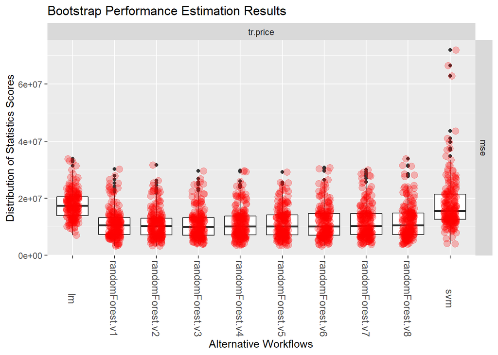

```r
plot(results1)
```

#### Baseline metric

```r
regressionMetrics(ts$price, base)
```

```
##          mae          mse         rmse         mape         <NA>
## 5.190555e+03 4.430135e+07 6.655926e+03 4.918835e-01           NA
```

#### First prediction

Based on all numerical variables for both random forest model and linear regression model.

```r
pred<- predict(random_forest_attempt, ts)

pred2 <- predict(full_model, ts)

regressionMetrics(ts$price, pred)
```

```
##          mae          mse         rmse         mape         <NA>
## 1.626353e+03 4.661080e+06 2.158954e+03 1.487177e-01           NA
```

```r
regressionMetrics(ts$price, pred2)
```

```
##          mae          mse         rmse         mape         <NA>
## 3.273992e+03 1.754541e+07 4.188725e+03 2.954956e-01           NA
```

```r
pres <- pairedComparisons(results1, baseline="randomForest.v3" )
pres$mse$WilcoxonSignedRank.test
```

```
## , , tr.price
##
##                 MedScore DiffMedScores      p.value
## randomForest.v3 10033339            NA           NA
## randomForest.v1 10480348    -447009.07 4.971222e-01
## randomForest.v2 10333801    -300462.47 9.091697e-01
## randomForest.v4 10157795    -124456.02 1.159324e-03
## randomForest.v5 10120280     -86941.79 3.904964e-04
## randomForest.v6 10094530     -61191.51 8.066232e-07
## randomForest.v7 10301630    -268290.91 5.133528e-09
## randomForest.v8 10519210    -485871.06 3.088939e-10
## lm              17377750   -7344411.73 2.124974e-33
## svm             15606901   -5573562.52 6.794822e-28
```

```r
signifDiffs(pres, p.limit=0.05)
```

```
## $mse
## $mse$WilcoxonSignedRank.test
## $mse$WilcoxonSignedRank.test$tr.price
##                 MedScore DiffMedScores      p.value
## randomForest.v3 10033339            NA           NA
## randomForest.v4 10157795    -124456.02 1.159324e-03
## randomForest.v5 10120280     -86941.79 3.904964e-04
## randomForest.v6 10094530     -61191.51 8.066232e-07
## randomForest.v7 10301630    -268290.91 5.133528e-09
## randomForest.v8 10519210    -485871.06 3.088939e-10
## lm              17377750   -7344411.73 2.124974e-33
## svm             15606901   -5573562.52 6.794822e-28
##
##
## $mse$t.test
## $mse$t.test$tr.price
##                 AvgScore DiffAvgScores      p.value
## randomForest.v3 11022789            NA           NA
## randomForest.v4 11308243     -285453.8 7.552811e-04
## randomForest.v5 11346337     -323548.0 1.832590e-03
## randomForest.v6 11637289     -614500.3 8.656035e-07
## randomForest.v7 11742435     -719646.2 2.154553e-08
## randomForest.v8 11935237     -912447.9 2.066403e-09
## lm              17786398    -6763609.4 4.017752e-67
## svm             18056574    -7033785.7 1.032827e-26
```

As you can see from the above paired comparison table, using the random forest (version 3) as a baseline, the random forest models performed significantly better than either the linear model or the svm . These values suggest a significant result.

As shown above, the random forest versions 4-8, as well as the svm and linear model all show significant results based on a 95% confidence interval.

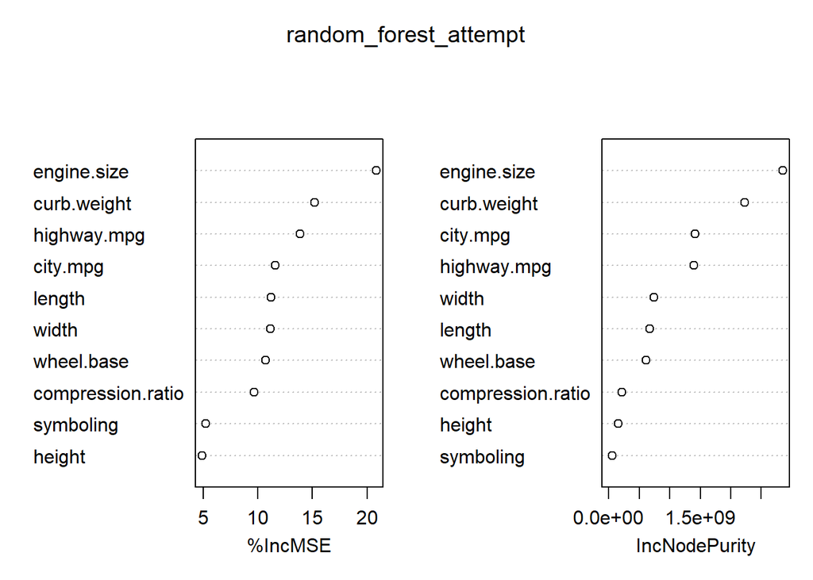

```r
varImpPlot(random_forest_attempt)
```

## Conclusion:

As we can see from the graphs above, engine size and curb weight seem to be the most important factors, which I found very odd. Engine size would normally be considered an important factor in price, but curb weight surprised me. However, based on my personal experience, I could extrapolate curb weight, in this instance, to a parameter of driving factors (top speed and shortest brake distance), which could then raise its level of importance, as top speed and max brake distance are both used as metrics for valuation of vehicles today.